# Data Exploration: Restaurant timings

Urvi Kalia

17 August 2016

## Introduction

The purpose of this documentation is to showcase the findings of the exploratory data analysis on given restaurant data.

To brief about the dataset , It contains a bunch of restaurant names and their open hours.The given data is preprocessed and converted to a convenient to use format.

## Exploratory Analysis

From the given data , few variables are dervied.This includes open duration for every weekday, total open duration for a week, weekday and weekends.Restaurants are also day wise categorized with respect to options available i.e. breakfast, lunch, dinner and their combinations based on their timings. Options being served are categorized as:

- breakfast
- lunch
- dinner
- breakfast & lunch
- breakfast & dinner
- lunch & dinner
- all (i.e. breakfast , lunch, dinner all three are served)

Below are timings for breakfast, lunch and dinner being considered.

- breakfast : 7:00 am - 10:30 am
- lunch : 12:00 pm - 3:00 pm
- dinner : 7:00 pm - 11:00 pm

### Duration

Considering the total open time period over the week, weekdays and weekends.Few of the findings are listed below :

| Condition | Longest Open | Shortest Open |
| --- | --- | --- |
| Weekly [Mon-Sun] | Naan ‘N’ Curry | Sam’s Grill & Seafood Restaurant |
| Weekdays [Mon-Fri] | Naan ‘N’ Curry | Sudachi |
| Weekends [Sat-Sun] | Naan ‘N’ Curry | Sam’s Grill & Seafood Restaurant |

#### Longest open restaurant day wise

| Day | Restaurant | Approx. Duration (hrs) |
| --- | --- | --- |
| Monday | Naan ‘N’ Curry | 17 |
| Tuesday | Naan ‘N’ Curry | 17 |
| Wednesday | Naan ‘N’ Curry | 17 |
| Thursday | Naan ‘N’ Curry | 17 |
| Friday | Naan ‘N’ Curry | 17 |
| Saturday | Naan ‘N’ Curry | 17 |
| Sunday | Naan ‘N’ Curry | 17 |

#### Shortest open restaurant day wise

| Day | Restaurant | Approx. Duration (hrs) |
| --- | --- | --- |
| Monday | Sudachi | 7.5 |
| Tuesday | Sudachi | 7.5 |
| Wednesday | Sudachi | 7.5 |
| Thursday | Sudachi, Marrakech Moroccan Restaurant | 8.5 |
| Friday | Sudachi, Marrakech Moroccan Restaurant | 8.5 |
| Saturday | Sam’s Grill & Seafood Restaurant | 4 |
| Sunday | New Delhi Indian Restaurant | 4.5 |

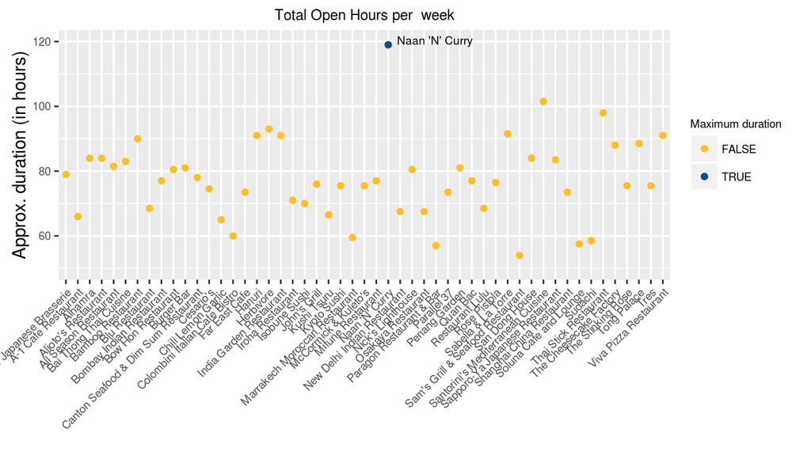

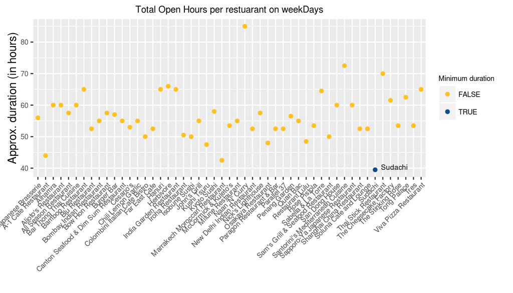

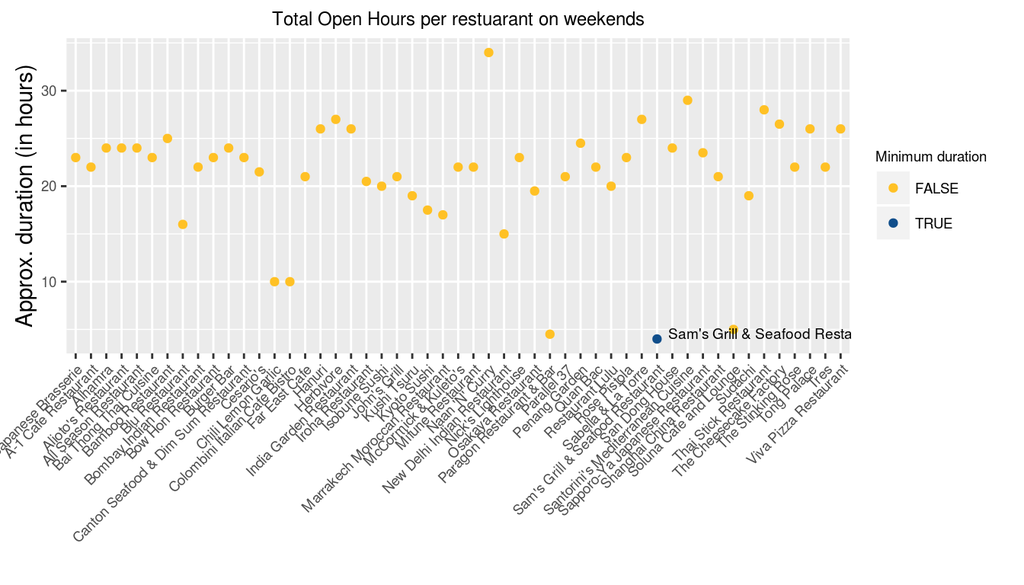

### Weekly Off

Only four restaurants , seams to take a weekly off.One on tuesday and rest on sunday as depicted below.

| Day | Restaurant |
| --- | --- |
| Tuesday | A-1 Cafe Restaurant |
| Sunday | Paragon Restaurant & Bar, Sam’s Grill & Seafood Restaurant, Soluna Cafe and Lounge |

### Distribution

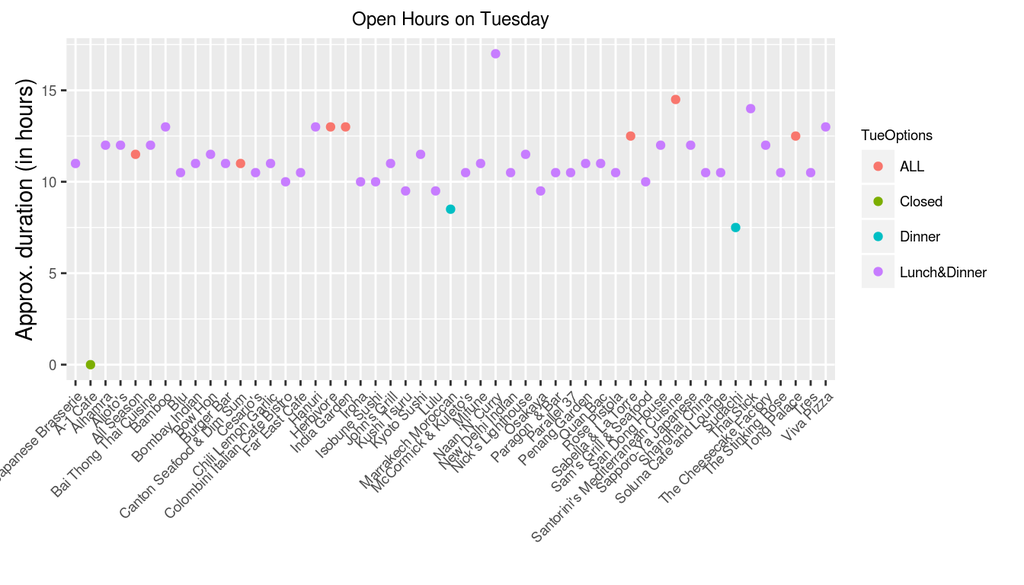

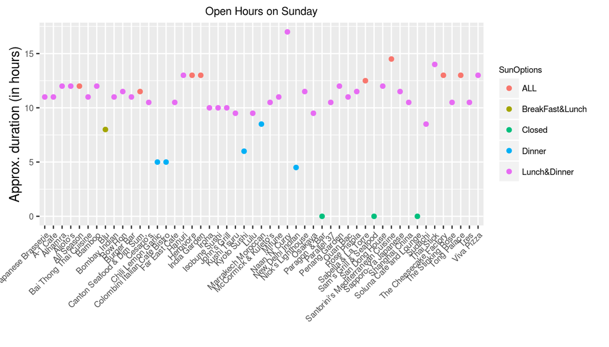

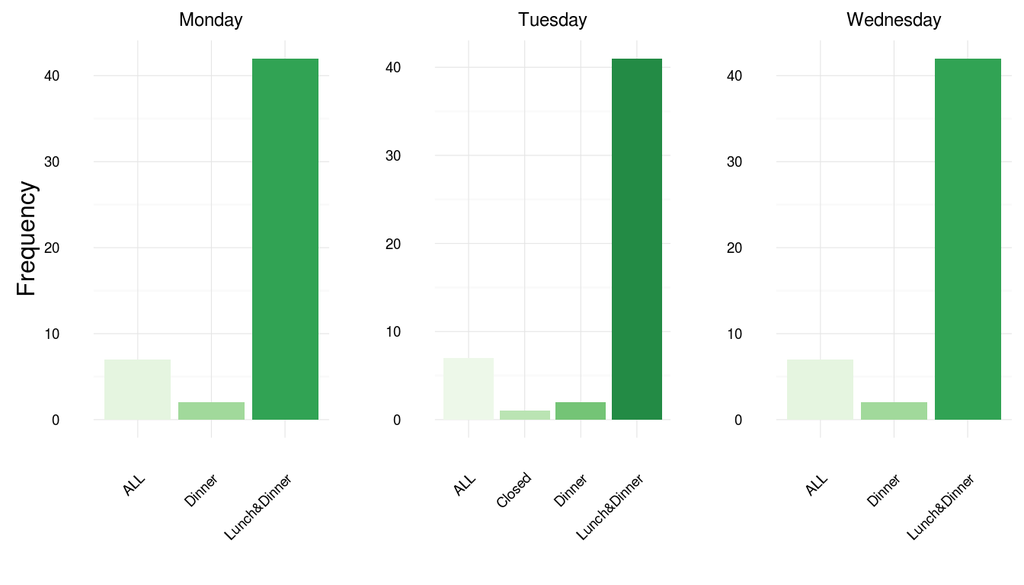

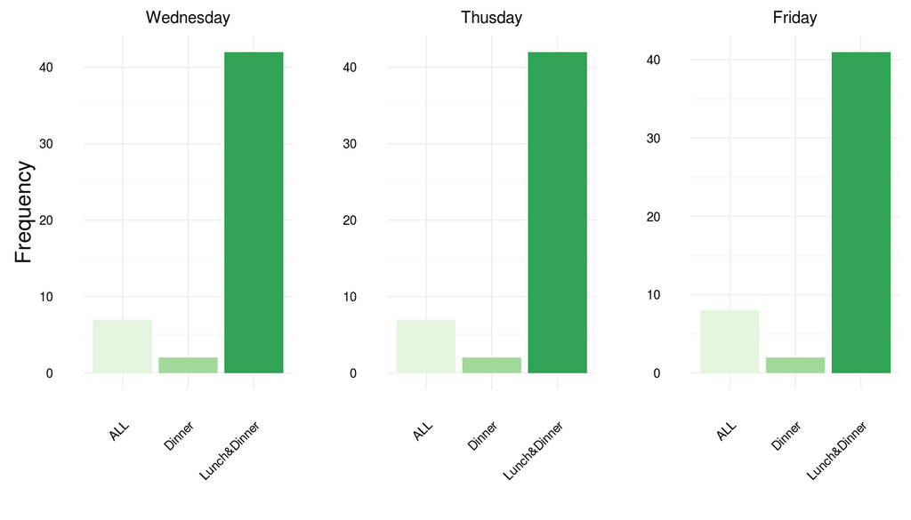

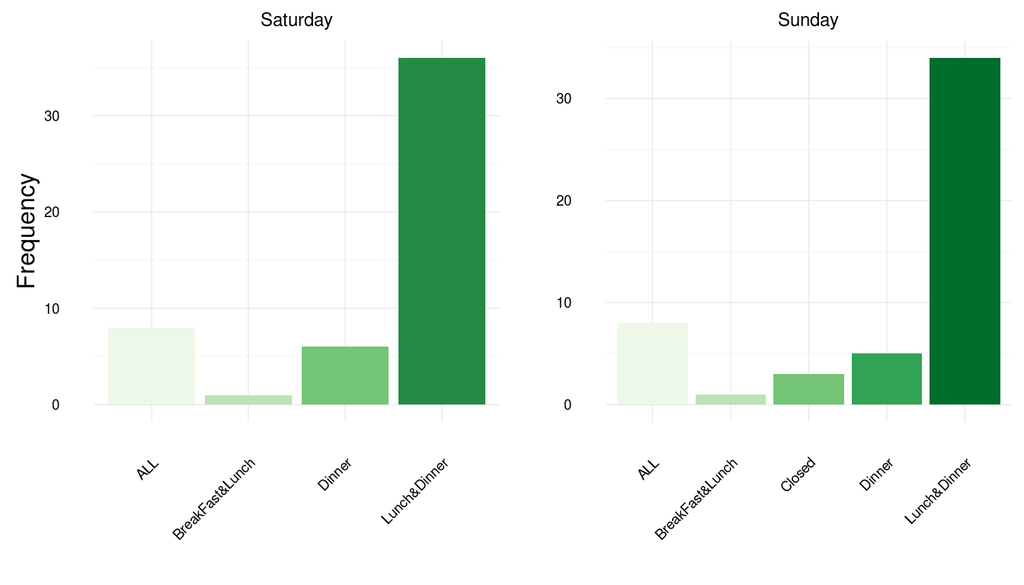

#### Others

1. On weekdays ,80% of the restaurants open at around 11 am / 11:30 am.
2. Other that Friday , Saturaday and Sunday , around 40% of the restaurants are open till 10 pm.
3. Friday and Saturday Nights , Number of restaurants open till 11 pm are almost double that on any weekday.